# Bayesian linear models

Author

Murray Logan

Published

July 9, 2026

# 1 Preparations

Load the necessary libraries

```r
library(tidyverse)   #for data wrangling and plotting
library(DHARMa)      #for simulated residuals
library(performance) #for model diagnostics
library(see)         #for model diagnostics
library(brms)        #for Bayesian models
library(tidybayes)   #for exploring Bayesian PKPDmodels
library(rstan)       #for diagnostics plots
library(bayesplot)   #for diagnostic plots
library(patchwork)   #for arranging multiple plots
library(HDInterval)  #for HPD intervals
library(bayestestR)  #for ROPE
library(emmeans)     #for estimated marginal means
source("helperfunctions.R")
```

Many biologists and ecologists get a little twitchy and nervous around mathematical and statistical formulae and nomenclature. Whilst it is possible to perform basic statistics without too much regard for the actual equation (model) being employed, as the complexity of the analysis increases, the need to understand the underlying model becomes increasingly important. Moreover, model specification in BUGS (the language used to program Bayesian modelling) aligns very closely to the underlying formulae. Hence a good understanding of the underlying model is vital to be able to create a sensible Bayesian model. Consequently, I will always present the linear model formulae along with the analysis. If you start to feel some form of disorder starting to develop, you might like to run through the Tutorials and Workshops twice (the first time ignoring the formulae).

# 2 A philosophical note

To introduce the philosophical and mathematical differences between classical (frequentist) and Bayesian statistics, Wade (2000) presented a provocative yet compelling trend analysis of two hypothetical populations. The temporal trend of one of the populations shows very little variability from a very subtle linear decline. By contrast, the second population appears to decline more dramatically, yet has substantially more variability.

Wade (2000) neatly illustrates the contrasting conclusions (particularly with respect to interpreting probability) that would be drawn by the frequentist and Bayesian approaches and in so doing highlights how and why the Bayesian approach provides outcomes that are more aligned with management requirements.

This tutorial will start by replicating the demonstration of Wade (2000).

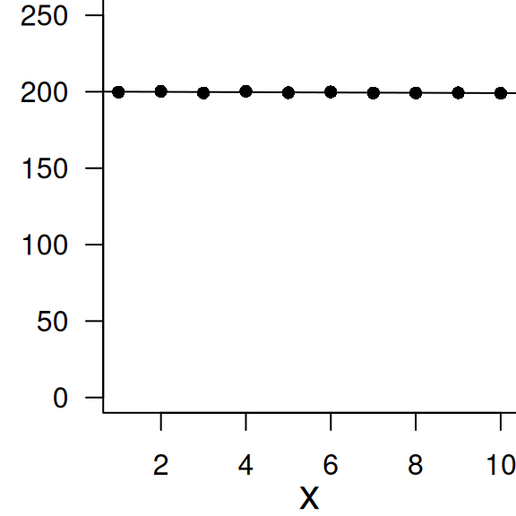

n: 10  
Slope: -0.1022  
*t*: -2.3252  
*p-value*: 0.0485

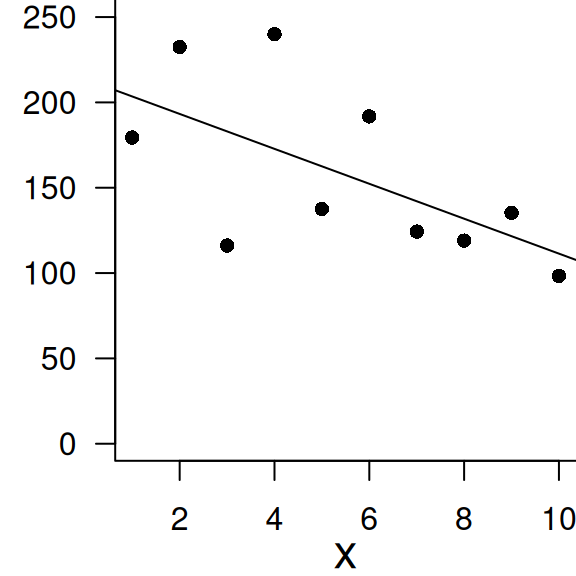

n: 10  
Slope: -10.2318  
*t*: -2.2115  
*p-value*: 0.0579

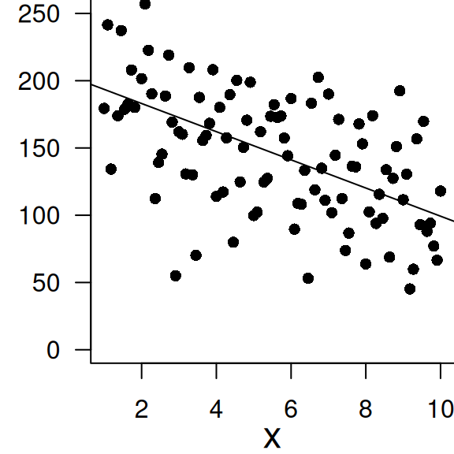

n: 100  
Slope: -10.4713  
*t*: -6.6457  
*p-value*: 0

From a traditional frequentist perspective, we would conclude that there is a ‘significant’ relationship in Population A and C ($p<0.05$), yet not in Population B ($p>0.05$). Note, Population B and C were both generated from the same random distribution, it is just that Population C has a substantially higher number of observations.

The above illustrates a couple of things

Let us now look at it from a Bayesian perspective. I will just provide the posterior distributions (densities scaled to 0-1 so that they can be plotted together) for the slope for each population.

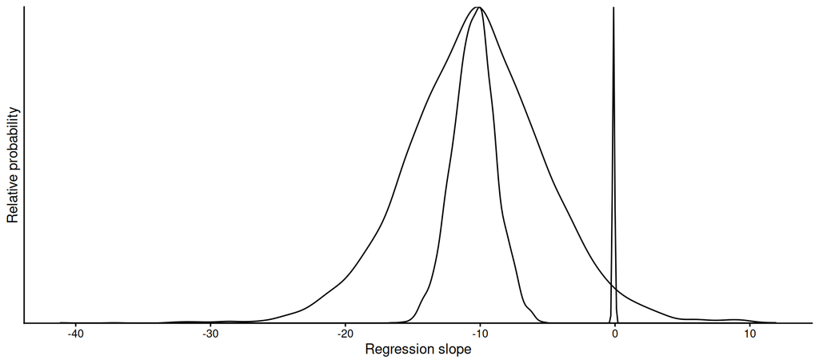

Focusing on Populations A and B, we would conclude:

- the mean (plus or minus CI) slopes for Population A and B are -0.1 (-0.22,0.01) and -10.32 (-20.79,0.11) respectively.
- the Bayesian approach allows us to query the posterior distribution is many other ways in order to ask sensible biological questions. For example, we might consider that a rate of change of 5% or greater represents an important biological impact. For Population A and B, the probability that the rate is 5% or greater is 0 and 0.86 respectively.
- the Bayesian approach allows us to query the posterior distribution is many other ways in order to ask sensible biological questions. For example, we might consider that a rate of change of 5% or greater represents an important biological impact. For Population A and B, the probability that the rate is 5% or greater is 0 and 0.86 respectively.

# 3 Review of (generalised) linear models

I would highly recommend reviewing the information in the tutorial on generalised linear models, particularly the sections describe linear models, assumption checking and generalised linear models (GLM). Whilst there are philosophical differences between frequentist and Bayesian statistics that have implications for how models are fit and interpreted, model choice and assumption checking principles are common between the two approaches. Hence, many of these topics will be assumed, and not fully described in the current tutorial.

Recall from the tutorial on generalised linear models that simple linear regression is a linear modelling process that models a single response variable against one or more predictors with a linear combination of coefficients and (in the case of a Gaussian model) can be expressed as:

$$y_i = \beta_0+ \beta_1 x_i+\epsilon_i \hspace{1cm}\epsilon\sim{}N(0,\sigma^2)$$

where:

- $y_i$ is the response value for each of the $i$ observations
- $\beta_0$ is the y-intercept (value of $y$ when $x=0$)
- $\beta_1$ is the slope (rate of chance in $y$ per unit chance in $x$)
- $x_i$ is the predictor value for each of the $i$ observations
- $\epsilon_i$ is the residual value of each of the $i$ observations. A residual is the difference between the observed value and the value expected by the model.
- $\epsilon\sim{}N(0,\sigma^2)$ indicates that the residuals are normally distributed with a constant amount of variance

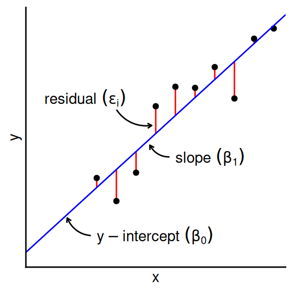

The above can be re-expressed and generalised as:
$$y_i\sim{}Dist(\mu_i, ...)\\
g(\mu_i) = \beta_0+ \beta_1 x_i$$

where:

- $Dist$ represents a distribution from the exponential family (such as Gaussian, Poisson, Binomial, etc)
- $...$ represents additional parameters relevant to the nominated distribution (such as $\sigma^2$: Gaussian, $n$: Binomial and $\phi$: Negative Binomial, etc)
- $g()$ represents the link function (e.g. log: Poisson, logit: Binomial, etc)

The reliability of any model depends on the degree to which the data adheres to the model assumptions. Hence, as with frequentist models, exploratory data analysis (EDA) is a vital component of Bayesian modelling and since the model structures are similar between frequentist and Bayesian approaches, so too is EDA.

# 4 Bayesian (generalised) linear models

For the purpose of introduction, we will start by exploring a Gaussian model with a very simple fabricated data set representing the relationship between a response ($y$) and a continuous predictor ($x = [1,2,3,4,5,6,7,8,9,10]$. The fabricated data set will comprise 10 observations each drawn from normal distributions with a set standard deviation of 4. The means of the 10 populations will be determined by the following equation:

$$\mu_i = 2 + 5\times x_i$$

Let generate these data.

```r
set.seed(234)
dat <- data.frame(x = 1:10) |>
    mutate(y = round(rnorm(n = 10, mean = 2 + (5 * x), sd = 4), digits = 2))
dat
```

```
    x     y
1   1  9.64
2   2  3.79
3   3 11.00
4   4 27.88
5   5 32.84
6   6 32.56
7   7 37.84
8   8 29.86
9   9 45.05
10 10 47.65
```

The model will will be fitting will be:

$$\begin{align}
y_i&\sim{}N(\mu_i, \sigma^2)\\
\mu_i &= \beta_0+ \beta_1 x_i
\end{align}$$

The parameters that we are going to attempt to estimate are the y-intercept ($\beta_0$), the slope ($\beta_1$) and the underlying variance ($\sigma^2$). Recall (from tutorials on statistical philosophies and estimation)) that Bayesian models calculate **posterior** predictions ($P(H|D)$) from likelihood ($P(D|H)$) and **prior** expectations ($P(H)$). Therefore, in preparation for fitting a Bayesian model, we must consider what our prior expectations are for *all* parameters.

The individual responses ($y_i$, observed yields) are each expected to have been **independently** drawn from normal (**Gaussian**) distributions ($\mathcal{N}$). These distributions represent all the possible values of $y$ we could have obtained at the specific ($i^{th}$) level of $x$. Hence the $i^{th}$ $y$ observation is expected to have been drawn from a normal distribution with a mean of $\mu_i$.

Although each distribution is expected to come from populations that differ in their means, we assume that all of these distributions have the **same variance** ($\sigma^2$).

## 4.1 Priors

We need to supply priors for each of the parameters to be estimated ($\beta_0$, $\beta_1$ and $\sigma$). Whilst we want these priors to be sufficiently vague as to not influence the outcomes of the analysis (and thus be equivalent to the frequentist analysis), we do not want the priors to be so vague (wide) that they permit the MCMC sampler to drift off into parameter space that is both illogical as well as numerically awkward.

Proffering sensible priors is one of the most difficult aspects of performing Bayesian analyses. For instances where there are some previous knowledge available and a desire to incorporate those data, the difficulty is in how to ensure that the information is incorporated correctly. However, for instances where there are no previous relevant information and so a desire to have the posteriors driven entirely by the new data, the difficulty is in how to define priors that are both vague enough (not bias results in their direction) and yet not so vague as to allow the MCMC sampler to drift off into unsupported regions (and thus get stuck and yield spurious estimates).

For early implementations of MCMC sampling routines (such as Metropolis Hasting and Gibbs), it was fairly common to see very vague priors being defined. For example, the priors on effects, were typically normal priors with mean of 0 and variance of `1e+06` (1,00,000). These are very vague priors. Yet for some samplers (e.g. NUTS), such vague priors can encourage poor behaviour of the sampler - particularly if the posterior is complex. It is now generally advised that priors should (where possible) be somewhat **weakly informative** and to some extent, represent the bounds of what are feasible and sensible estimates.

The degree to which priors **influence** an outcome (whether by having a pulling effect on the estimates or by encouraging the sampler to drift off into unsupported regions of the posterior) is dependent on:

- the relative sparsity of the data - the larger the data, the less weight the priors have and thus less influence they exert.
- the complexity of the model (and thus posterior) - the more parameters, the more sensitive the sampler is to the priors.

The sampled posterior is the product of both the likelihood and the prior - all of which are multidimensional. For most applications, it would be vertically impossible to define a sensible multidimensional prior. Hence, our only option is to define priors on individual parameters (e.g. the intercept, slope(s), variance etc) and to hope that if they are individually sensible, they will remain collectively sensible.

So having (hopefully) impressed upon the notion that priors are an important consideration, I will now attempt to synthesise some of the approaches that can be employed to arrive at weakly informative priors that have been gleaned from various sources. Largely, this advice has come from the following resources:

- https://github.com/stan-dev/stan/wiki/Prior-Choice-Recommendations
- http://svmiller.com/blog/2021/02/thinking-about-your-priors-bayesian-analysis/

I will outline some of the current main recommendations before summarising some approaches in a table.

- weakly informative priors should contain enough information so as to regularise (discourage unreasonable parameter estimates whilst allowing all reasonable estimates).
- for effects parameters on scaled (standardised) data, an argument could be made for a normal distribution with a standard deviation of 1 (e.g. `normal(0,1)`), although some prefer a *t* distribution with 3 degrees of freedom and standard deviation of 1 (e.g. `student_t(3,0,1)`) - apparently a flatter *t* is a more robust prior than a normal as an uninformative prior…
- for un-scaled data, the above priors can be scaled by using the standard deviation of the data as the prior standard deviation (e.g. `student_t(3,0,sd(y))`, or `sudent_t(3,0,sd(y)/sd(x))`)
- for priors of hierachical standard deviations, priors should encourage shrinkage towards 0 (particularly if the number of groups is small, since otherwise, the sampler will tend to be more responsive to “noise”).

In this tutorial series, we will perform Bayesian analysis in the STAN language via an R interface. Two popular interfaces that greatly simplify the specification of Bayesian models are [brms](https://paul-buerkner.github.io/brms/) and [rstanarm](https://mc-stan.org/rstanarm/). We will exclusively focus on the former as it is far more flexible.

| Family | Parameter | brms | rstanarm |
| --- | --- | --- | --- |
| Gaussian | Intercept | `student_t(3,median(y),mad(y))` | `normal(mean(y),2.5*sd(y))` |
|  | ‘Population effects’ (slopes, betas) | flat, improper priors | `normal(0,2.5*sd(y)/sd(x))` |
|  | Sigma | `student_t(3,0,mad(y))` | `exponential(1/sd(y))` |
|  | ‘Group-level effects’ | `student_t(3,0,mad(y))` | `decov(1,1,1,1)` |
|  | Correlation on group-level effects | `ljk_corr_cholesky(1)` |  |
| Poisson | Intercept | `student_t(3,median(y),mad(y))` | `normal(mean(y),2.5*sd(y))` |
|  | ‘Population effects’ (slopes, betas) | flat, improper priors | `normal(0,2.5*sd(y)/sd(x))` |
|  | ‘Group-level effects’ | `student_t(3,0,mad(y))` | `decov(1,1,1,1)` |
|  | Correlation on group-level effects | `ljk_corr_cholesky(1)` |  |
| Negative binomial | Intercept | `student_t(3,median(y),mad(y))` | `normal(mean(y),2.5*sd(y))` |
|  | ‘Population effects’ (slopes, betas) | flat, improper priors | `normal(0,2.5*sd(y)/sd(x))` |
|  | Shape | `gamma(0.01, 0.01)` | `exponential(1/sd(y))` |
|  | ‘Group-level effects’ | `student_t(3,0,mad(y))` | `decov(1,1,1,1)` |
|  | Correlation on group-level effects | `ljk_corr_cholesky(1)` |  |

Notes:

`brms`

https://github.com/paul-buerkner/brms/blob/c2b24475d727c8afd8bfc95947c18793b8ce2892/R/priors.R

1. In the above, for non-Gaussian families, `y` is first transformed according to the family link. If the family link is `log`, then 0.1 is first added to 0 values.
2. in `brms` the minimum standard deviation for the Intercept prior is `2.5`
3. in `brms` the minimum standard deviation for group-level priors is `10`.

`rstanarm`

http://mc-stan.org/rstanarm/articles/priors.html

1. in `rstanarm` priors on standard deviation and correlation associated with group-level effects are packaged up into a single prior (`decov` which is a decomposition of the variance and covariance matrix).

In my experience, I find that the above priors tend to be a little bit too wide for many ecological applications and I often prefer to use 1.5 rather than 2.5 as the multiplier.

**Note**

In Bayesian models, centering of predictors offers huge numerical advantages. So important is it to center that `brms` automatically centers any continuous predictors for you. However, since the user has not necessarily centered the predictors, the user might misinterpret the outputs from a `brms` model. Consequently, when fitting a model, `brms` also generates y-intercept values that are consistent with un-centered values and these are the estimates returned to the user.

Nevertheless, I would recommend that you should always explicitly center continuous predictors to provide more meaningful interpretations of the y-intercept. I would also highly recommend standardising continuous predictors - this will not only help speed up and stabilise the model, it will simplify the spefication of priors - see the specific examples later in this tutorial.

Based on the above, for our fabricated data, lets assign the following priors:

- $\beta_0$: Normal prior centred at 31.21 with a variance of 15.17
  - mean:

    ```r
    dat$y |> median() |> round(2)
    ```

    ```
    [1] 31.21
    ```

  - variance:

    ```r
    dat$y |> mad() |> round(2)
    ```

    ```
    [1] 15.17
    ```

- $\beta_1$: *t* distribution (3 degrees of freedom) prior centred at 0 with a variance of 4.09
  - mean: since effects are differences and we may not want to pre-determine the direction (polarity) of any trends, it is typical to define effects priors with means of 0
  - variance:

    ```r
    mad(dat$y) / mad(dat$x) |> round(2)
    ```

    ```
    [1] 4.090138
    ```

- $\sigma$: (half) *t* distribution (3 degrees of freedom) centred at 0 with a variance of 15.17
  - variance:

    ```r
    dat$y |> mad() |> round(2)
    ```

    ```
    [1] 15.17
    ```

Note, again, when fitting models through either `rstanarm` or `brms`, the priors assume that the predictor(s) have been centred and are to be applied on the link scale. In this case the link scale is an identity.

Similar logic can be applied for models that employ different distributions. In the following sections, we will define numerous sets of data (each of which represents different major forms of ecological data) and see how we can set appropriate priors in each case. In working through these example, it is worth reflecting on how much simpler prior specification is if we use standardised predictors.

# 5 Example data

This tutorial will blend theoretical discussions with actual calculations and model fits. I believe that by bridging the divide between theory and application, we all gain better understanding. The applied components of this tutorial will be motivated by numerous fabricated data sets. The advantage of simulated data over real data is that with simulated data, we know the ‘truth’ and can therefore gauge the accuracy of estimates.

The motivating examples are:

- **Example 1** - simulated samples drawn from a Gaussian (normal) distribution reminiscent of data collected on measurements (such as body mass)
- **Example 2** - simulated Gaussian samples drawn three different populations representing three different treatment levels (e.g. body masses of three different species)
- **Example 3** - simulated samples drawn from a Poisson distribution reminiscent of count data (such as number of individuals of a species within quadrats)
- **Example 4** - simulated samples drawn from a Negative Binomial distribution reminiscent of over-dispersed count data (such as number of individuals of a species that tends to aggregate in groups)
- **Example 5** - simulated samples drawn from a Bernoulli (binomial with $n = 1$) distribution reminiscent of binary data (such as the presence/absence of a species within sites)
- **Example 6** - simulated samples drawn from a Binomial distribution reminiscent of proportional data (such as counts of a particular taxa out of a total number of individuals)

**Example 1 (Gaussian data)**

Lets formally simulate the data illustrated above. The underlying process dictates that on average a one unit change in the predictor (`x`) will be associated with a five unit change in response (`y`) and when the predictor has a value of 0, the response will typically be 2. Hence, the response (`y`) will be related to the predictor (`x`) via the following:

$$y = 2 + 5x$$

This is a deterministic model, it has no uncertainty. In order to simulate actual data, we need to add some random noise. We will assume that the residuals are drawn from a Gaussian distribution with a mean of zero and standard deviation of 4. The predictor will comprise of 10 uniformly distributed integer values between 1 and 10. We will round the response to two decimal places.

For repeatability, a seed will be employed on the random number generator. Note, the smaller the dataset, the less it is likely to represent the underlying deterministic equation, so we should keep this in mind when we look at how closely our estimated parameters approximate the ‘true’ values. Hence, the seed has been chosen to yield data that maintain a general trend that is consistent with the defining parameters.

```r
set.seed(234)
dat <- data.frame(x = 1:10) |>
    mutate(y = round(2 + 5*x + rnorm(n = 10, mean = 0, sd = 4), digits = 2))
dat
```

```
    x     y
1   1  9.64
2   2  3.79
3   3 11.00
4   4 27.88
5   5 32.84
6   6 32.56
7   7 37.84
8   8 29.86
9   9 45.05
10 10 47.65
```

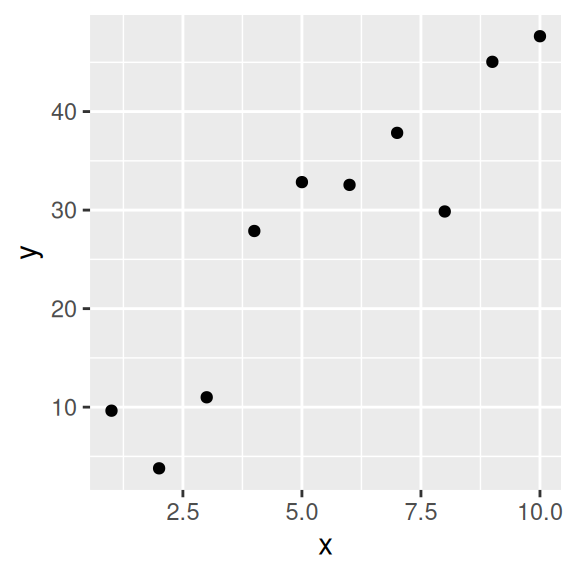

```r
ggplot(data = dat) +
geom_point(aes(y = y, x = x))
```

We will use these data in two ways. Firstly, to estimate the mean and variance of the reponse (`y`) ignoring the predcitor (`x`) and secondly to estimate the relationship between the reponse and predictor.

For the former, we know that the mean and variance of the response (`y`) can be calculated as:

$$\begin{align}
\bar{y} =& \frac{1}{n}\sum^n_{i=1}y_i\\
var(y) =& \frac{1}{n}\sum^n_{i=1}(y-\bar{y})^2\\
sd(y) =& \sqrt{var(y)}
\end{align}$$

```r
mean(dat$y)
```

```
[1] 27.811
```

```r
var(dat$y)
```

```
[1] 225.9111
```

```r
sd(dat$y)
```

```
[1] 15.03034
```

**Example 2 (categorical predictor)**

As previously described, categorical predictors are transformed into dummy codes prior to the fitting of the linear model. We will simulate a small data set with a single categorical predictor comprising a control and two treatment levels (‘mediam’, ‘high’). To simplify things we will assume a Gaussian distribution, however most of the modelling steps would be the same regardless of the chosen distribution.

```r
set.seed(123)
beta_0 <- 20
beta <- c(-2, -10)
sigma <- 4
n <- 12
x <- gl(3, 4, 12, labels = c('control', 'medium', 'high'))
y <- (model.matrix(~x) %*% c(beta_0, beta)) + rnorm(12, 0, sigma)
dat2 <- data.frame(x = x, y = y)
dat2
```

```
         x         y
1  control 17.758097
2  control 19.079290
3  control 26.234833
4  control 20.282034
5   medium 18.517151
6   medium 24.860260
7   medium 19.843665
8   medium 12.939755
9     high  7.252589
10    high  8.217352
11    high 14.896327
12    high 11.439255
```

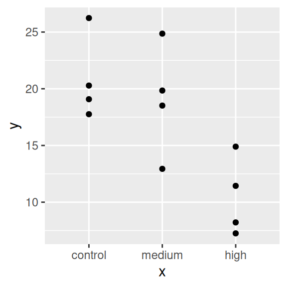

```r
ggplot(data = dat2) +
geom_point(aes(y = y, x = x))
```

**Example 3 (Poisson data)**

The Poisson distribution is only parameterized by a single parameter ($\lambda$) which represents both the mean and variance. Furthermore, Poisson data can only be positive integers.

Unlike simple trend between two Gaussian or uniform distributions, modelling against a Poisson distribution alters the scale to logarithms. This needs to be taken into account when we simulate the data. The parameters that we used to simulate the underlying processes need to either be on a logarithmic scale, or else converted to a logarithmic scale prior to using them for generating the random data.

Moreover, for any model that involves a non-identity link function (such as a logarithmic link function for Poisson models), ‘slope’ is only constant on the scale of the link function. When it is back transformed onto the natural scale (scale of the data), it takes on a different meaning and interpretation.

```r
set.seed(123)
beta <- c(1, 1.40)
beta <- log(beta)
n <- 10
dat3 <- data.frame(x=seq(from = 1, to = 10, len = n)) |>
    mutate(y = rpois(n, lambda = exp(beta[1] + beta[2]*x)))
dat3
```

```
    x  y
1   1  1
2   2  3
3   3  2
4   4  6
5   5  9
6   6  3
7   7 10
8   8 15
9   9 28
10 10 31
```

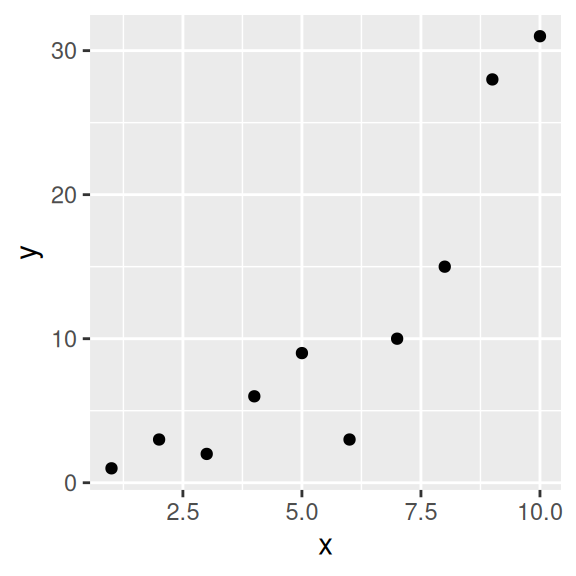

```r
ggplot(data = dat3) +
geom_point(aes(y = y, x = x))
```

**Example 4 (NB data)**

Over dispersed models under-estimate the variability and thus precision in estimates resulting in inflated confidence in outcomes (elevated Type I errors).

There are numerous causes of over-dispersed count data (one of which is eluded to above). These are:

- additional sources of variability not being accounted for in the model (see above)
- when the items being counted aggregate together. Although the underlying items may have been generated by a Poisson process, the items clump together. When the items are counted, they are more likely to be in either in relatively low or relatively high numbers - hence the data are more varied than would be expected from their overall mean.
- imperfect detection resulting in excessive zeros. Again the underlying items may have been generated by a Poisson process, however detecting and counting the items might not be completely straight forward (particularly for more cryptic items). Hence, the researcher may have recorded no individuals in a quadrat and yet there was one or more present, they were just not obvious and were not detected. That is, layered over the Poisson process is another process that determines the detectability. So while the Poisson might expect a certain proportion of zeros, the observed data might have a substantially higher proportion of zeros - and thus higher variance.

This example will generate data that is drawn from a negative binomial distribution so as to broadly represent any one of the above causes.

```r
set.seed(234)
beta <- c(1, 1.40)
beta <- log(beta)
n <- 10
size <- 10
dat4 <- data.frame(x = seq(from = 1, to = 10, len = n)) |>
    mutate(
        mu = exp(beta[1] + beta[2] * x),
        y = rnbinom(n, size = size, mu =  mu)
    )
dat4
```

```
    x        mu  y
1   1  1.400000  0
2   2  1.960000  3
3   3  2.744000  7
4   4  3.841600  3
5   5  5.378240  5
6   6  7.529536  9
7   7 10.541350 13
8   8 14.757891 10
9   9 20.661047 17
10 10 28.925465 26
```

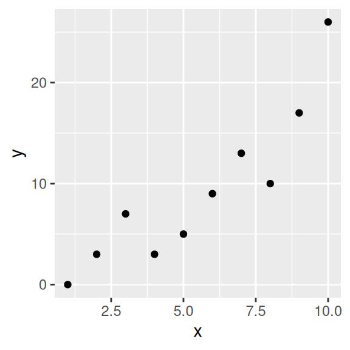

```r
ggplot(data = dat4) +
geom_point(aes(y = y, x = x))
```

**Example 5 (Binary data)**

Binary data (presence/absence, dead/alive, yes/no, heads/tails, etc) pose unique challenges for linear modeling. Linear regression, designed for continuous outcomes, may not be directly applicable to binary responses. The nature of binary data violates assumptions of normality and homoscedasticity, which are fundamental to linear regression. Furthermore, linear models may predict probabilities outside the [0, 1] range, leading to unrealistic predictions.

This example will generate data that is drawn from a bernoulli distribution so as to broadly represent presence/absence data.

```r
set.seed(234)
beta <- c(0.02, 2)
beta <- log(beta)
n <- 10
dat5 <- data.frame(x = seq(from = 1, to = 10, len = n)) |>
    mutate(
        y = as.numeric(rbernoulli(n, p = plogis(beta[1] + beta[2] * x)))
    )
dat5
```

```
    x y
1   1 0
2   2 0
3   3 0
4   4 1
5   5 0
6   6 1
7   7 1
8   8 1
9   9 1
10 10 1
```

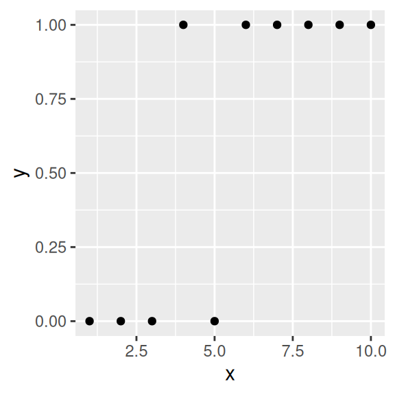

```r
ggplot(data = dat5) +
geom_point(aes(y = y, x = x))
```

**Example 6 (Binomial data)**

Similar to binary data, proportional (binomial) data tend to violate normality and homogeneity of variance (particularly as mean proportions approach either 0% or 100%.

This example will generate data that is drawn from a binomial distribution so as to broadly represent proportion data.

We will chose $\beta_0$ to represent the odds of a particular trial (e.g. an individual) being of a particular type (e.g. species 1) when $x=0$ and to equal to $0.02$. This is equivalent to a probability of $y$ being of the focal type when $x=0$ of $\frac{0.02}{1+0.02}=0.0196$. E.g., at low $x$, the the probability that an individual is taxa 1 is likely to be close to 0. For every one unit increase in $x$, we will stipulate a 2.5 times increase in odds that the expected response is equal to 1.

For this example, we will also convert the counts into proportions ($y2$) by division with the number of trials ($5$).

```r
set.seed(123)
beta <- c(0.02, 2.5)
beta <- log(beta)
n <- 10
trials <- 5
dat6 <- data.frame(x = seq(from = 1, to = 10, len = n)) |>
    mutate(
      count = as.numeric(rbinom(n, size = trials, prob = plogis(beta[1] + beta[2] * x))),
      total = trials,
      y = count/total
    )
dat6
```

```
    x count total   y
1   1     0     5 0.0
2   2     1     5 0.2
3   3     1     5 0.2
4   4     4     5 0.8
5   5     2     5 0.4
6   6     5     5 1.0
7   7     5     5 1.0
8   8     4     5 0.8
9   9     5     5 1.0
10 10     5     5 1.0
```

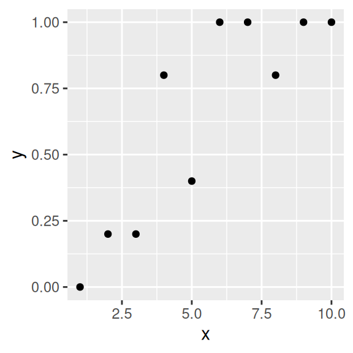

```r
ggplot(data = dat6) +
geom_point(aes(y = y, x = x))
```

# 6 Exploratory data analysis

Statistical models utilize data and the inherent statistical properties of distributions to discern patterns, relationships, and trends, enabling the extraction of meaningful insights, predictions, or inferences about the phenomena under investigation. To do so, statistical models make assumptions about the likely distributions from which the data were collected. Consequently, the reliability and validity of any statistical model depend upon adherence to these underlying assumptions.

Exploratory Data Analysis (EDA) and assumption checking therefore play pivotal roles in the process of statistical analysis, offering essential tools to glean insights, assess the reliability of statistical methods, and ensure the validity of conclusions drawn from data. EDA involves visually and statistically examining datasets to understand their underlying patterns, distributions, and potential outliers. These initial steps provides an intuitive understanding of the data’s structure and guides subsequent analyses. By scrutinizing assumptions, such as normality, homoscedasticity, and independence, researchers can identify potential limitations or violations that may impact the accuracy and reliability of their findings.

Exploratory Data Analysis within the context of ecological statistical models usually comprise a set of targetted graphical summaries. They are not to be considered definitive diagnostics of the model assumptions, but rather a first pass to assess the obvious violations prior to the fitting of models. More definitive diagnostics can only be achieved after a model has been fit.

In addition to graphical summaries, there are numerous statistical tests to help explore possible violations of various statistical assumptions. These tests are less commonly used in ecology since they are often more sensitive to deviations from ideal than are the models that we are seeking to ensure.

Simple classic regression models are often the easiest models to fit and interpret and as such often represent a standard by which other alternate models are gauged. As you will see later in this tutorial, such models can actually be fit using closed form (exact solution) matrix algebra that can be performed by hand. Nevertheless, and perhaps as a result, they also impose some of the strictest assumptions. Although these collective assumptions are specific to gaussian models, they do provide a good introduction to model assumptions in general, so we will use them to motivate the more wider discussion.

Simple (gaussian) linear models (represented below) make the following assumptions:

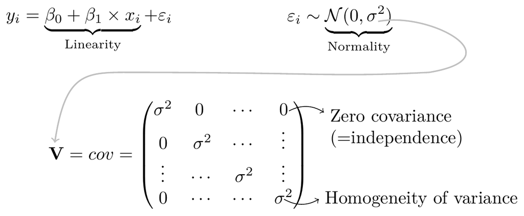

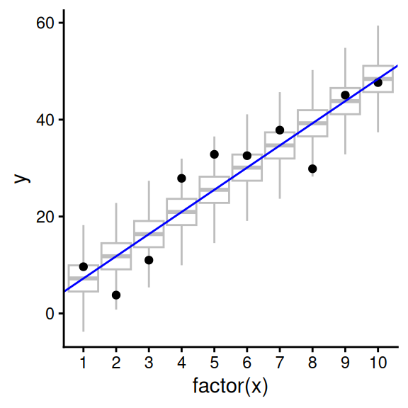

**NoteNotes on the data depicted above**

The data depicted above where generated using the following R codes:

```r
set.seed(234)
x <- 1:10
y <- 2 + (5*x) + rnorm(10,0,4)
```

The observations represent

- single observations drawn from 10 normal populations
- each population had a standard deviation of 4
- the mean of each population varied linearly according to the value of x ($2 + 5x$)
- **normality**: the residuals (and thus observations) must be drawn from populations that are normal distribution. *The right hand figure underlays the ficticious normally distributed populations from which the observed values have been sampled*.

**NoteMore information about assessing normality**

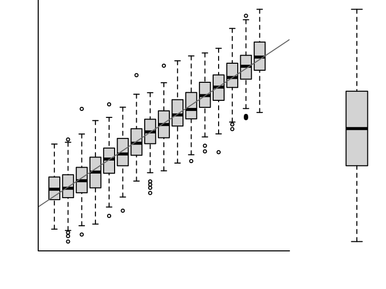

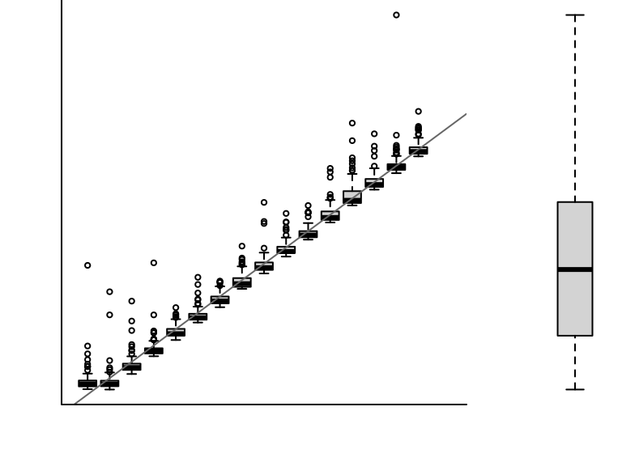

For a given response, the population distributions should follow much the same distribution shapes. Therefore provided the single samples from each population are unbiased representations of those populations, a boxplot of all observations should reflect the population distributions.

The two figures above show the relationships between the individual population distributions and the overall distribution. The left hand figure shows a distribution drawn from single representatives of each of the 16 populations. Since the 16 individual populations were normally distributed, the distribution of the 16 observations is also normal.

By contrast, the right hand figure shows 16 log-normally distributed populations and the resulting distribution of 16 single observations drawn from these populations. The overall boxplot mirrors each of the individual population distributions.

Whilst traditionally, non-normal data would typically be **normalised** via a scale transformation (such as a logarithmic transformation), these days it is arguably more appropriate to attempt to match the data to a more suitable distribution (see later in this tutorial).

You may have noticed that we have only explored the distribution of the response (y-axis). What about the distribution of the predictor (independent, x-axis) variable, does it matter? The distribution assumption applies to the residuals (which as purely in the direction of the y-axis). Indeed technically, it is assumed that there is no uncertainty associated with the predictor variable. They are assumed to be set and thus there is no error associated with the values observed. Whilst this might not always be reasonable, it is an assumption.

Given that the predictor values are expected to be *set* rather than *measured*, we actually assume that they are **uniformly** distributed. In practice, the exact distribution of predictor values is not that important provided it is reasonably symmetrical and no outliers (unusually small or large values) are created as a result of the distribution.

As with exploring the distribution of the response variable, boxplots, histograms and density plots can be useful means of exploring the distribution of predictor variable(s). When such diagnostics reveal distributional issues, scale transformations (such as logarithmic transformations) are appropriate.

- **homogeneity of variance**: the residuals (and thus observations) must be drawn from populations that are equally varied. The model as shown only estimates a single variance ($\sigma^2$) parameter - it is assumed that this is a good overall representation of all underlying populations. *The right hand figure underlays the ficticious normally distributed and equally varied populations from which the observations have been sampled*.

  Moreover, since the expected values (obtained by solving the deterministic component of the model) and the variance must be estimated from the same data, they need to be independent (not related one another)

**NoteMore information about assessing homogeneity of variance**

Simple linear regression also assumes that each of the populations are equally varied. Actually, it is the prospect of a relationship between the mean and variance of y-values across x-values that is of the greatest concern. Strictly the assumption is that the distribution of y values at each x value are equally varied and that there is no relationship between mean and variance.

However, as we only have a single y-value for each x-value, it is difficult to directly determine whether the assumption of homogeneity of variance is likely to have been violated (mean of one value is meaningless and variability can’t be assessed from a single value). The figure below depicts the ideal (and almost never realistic) situation in which (left hand figure) the populations are all equally varied. The middle figure simulates drawing a single observation from each of the populations. When the populations are equally varied, the spread of observed values around the trend line is fairly even - that is, there is no trend in the spread of values along the line.

If we then plot the residuals (difference between observed values and those predicted by the trendline) against the predict values, there is a definite lack of pattern. This lack of pattern is indicative of a lack of issues with homogeneity of variance.

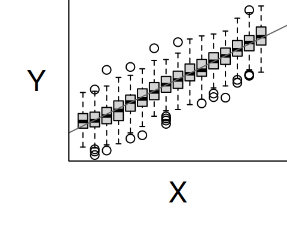

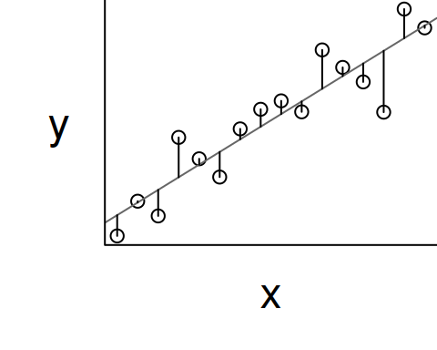

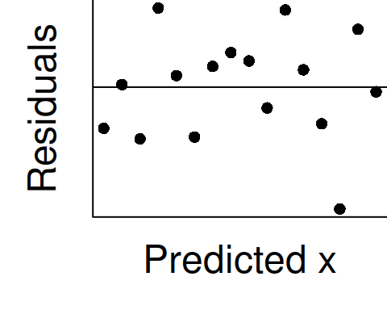

If we now contrast the above to a situation where the population variance is related to the mean (unequal variance), we see that the observations drawn from these populations are not evenly distributed along the trendline (they get more spread out as the mean predicted value increase). This pattern is emphasized in the residual plot which displays a characteristic “wedge”-shape pattern.

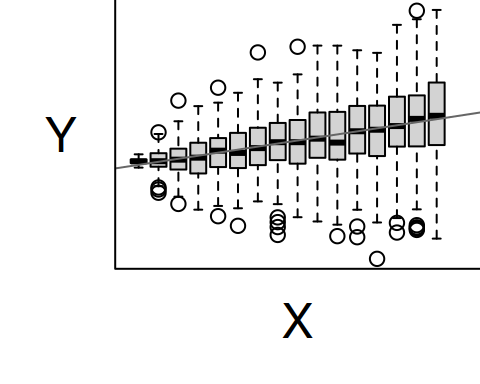

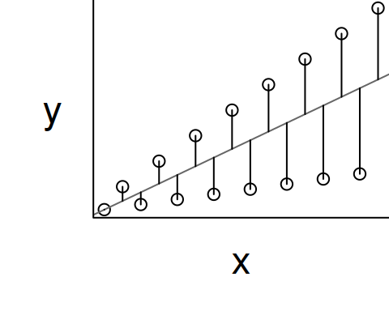

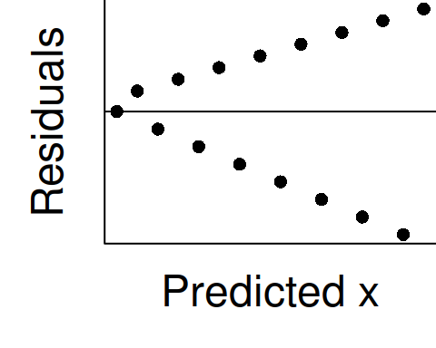

Hence looking at the spread of values around a trendline on a scatterplot of $y$ against $x$ is a useful way of identifying gross violations of homogeneity of variance. Residual plots provide an even better diagnostic. The presence of a wedge shape is indicative that the population mean and variance are related.

- **linearity**: the underlying relationships must be simple linear trends, since the line of best fit through the data (of which the slope is estimated) is linear. *The right hand figure depicts a linear trend through the underlying populations*.

**NoteMore information about assessing linearity**

It is important to disclose the meaning of the word “linear” in the term “linear regression”. Technically, it refers to a *linear* combination of regression coefficients. For example, the following are examples of linear models:

- $y_i = \beta_0 + \beta_1 x_i$
- $y_i = \beta_0 + \beta_1 x_i + \beta_2 z_i$
- $y_i = \beta_0 + \beta_1 x_i + \beta_2 x^2_i$

All the coefficients ($\beta_0$, $\beta_1$, $\beta_2$) are linear terms. Note that the last of the above examples, is a linear model, however it describes a non-linear trend. Contrast the above models with the following non-linear model:

- $y_i = \beta_0 + x_i^{\beta_1}$

In that case, the coefficients are not linear combinations (one of them is a power term).

That said, a simple linear regression usually fits a straight (linear) line through the data. Therefore, prior to fitting such a model, it is necessary to establish whether this really is the most sensible way of describing the relationship. That is, does the relationship appear to be linearly related or could some other non-linear function describe the relationship better. Scatterplots and residual plots are useful diagnostics.

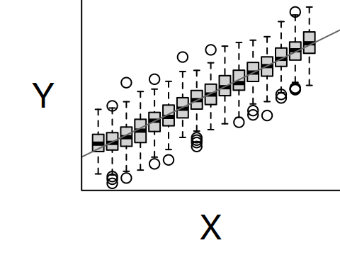

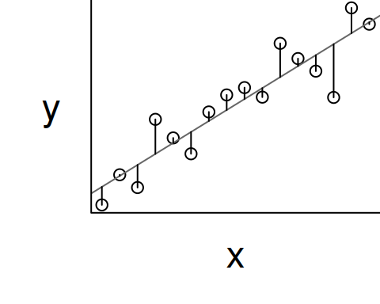

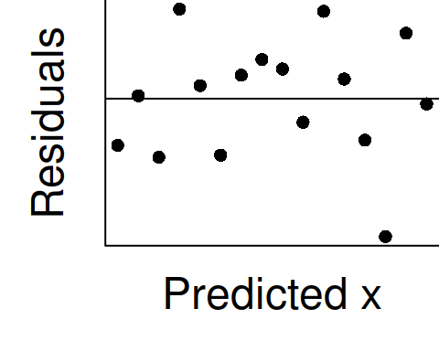

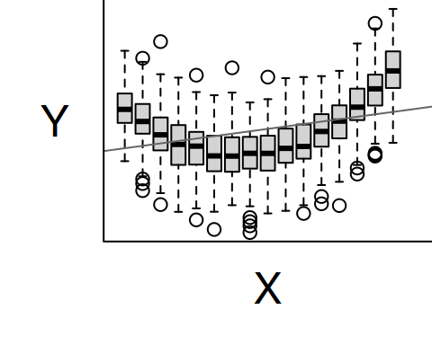

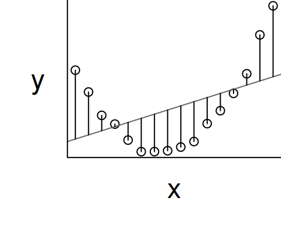

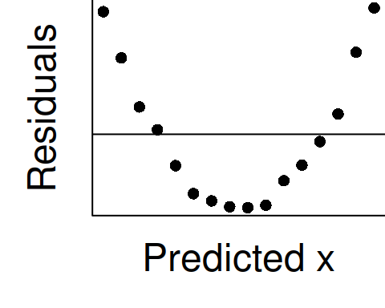

The above might be an obvious and somewhat overly contrived example, yet it does illustrate the point - that a pattern in the residuals could point to a mis-specified model.

If non-linearity does exist (as in the second case above) , then fitting a straight line through what is obviously not a straight relationship is likely to poorly represent the true nature of the relationship. There are numerous causes of non-linearity:

1. underlying distributional issues can result in non-linearity. For example, if we are assuming a gaussian distribution and the data are non-normal, often the relationships will appear non-linear. Addressing the distributional issues can therefore resolve the linearity issues
2. the underlying relationship might truly be non-linear in which case this should be reflected in some way by the model formula. If the model formula fails to describe the non-linear trend, then problems will persist.
3. the model proposed is missing an important covariate that might help standardise the data in a way that results in linearity
- **independence**: the residuals (and thus observations) must be independently drawn from the populations. That is, the correlation between all the observations is assumed to be 0 (off-diagonals in the covariance matrix). More practically, there should be no pattern to the correlations between observations.

  Random sampling and random treatment assignment are experimental design elements that are intended to mitigate many types of sampling biases that cause dependencies between observations. Nevertheless, there are aspects of sampling designs that are either logistically difficult to randomise or in some cases not logically possible. For example, the residuals from observations sampled closer together in space and time will likely be more similar to one another than those of observations more spaced apart. Since neither space nor time can be randomised, data collected from sampling designs that involve sampling over space and/or time need to be assess for spatial and temporal dependencies. These concepts will be explored in the context of introducing susceptible designs in a later tutorial.

The above is only a very brief overview of the model assumptions that apply to just one specific model (simple linear gaussian regression). For the remainder of this section, we will graphically explore the two motivating example data sets so as gain insights into what distributional assumptions might be most valid, and thus help guide modelling choices. Similarly, for subsequent tutorials in this series (that introduce progressively more complex models), all associated assumptions will be explored and detailed.

**Example 1 (Gaussian data)**

**Normality**

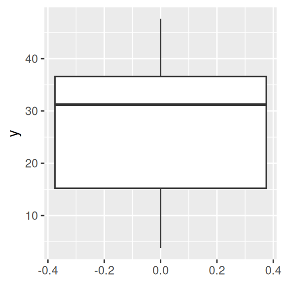

```r
dat |>
  ggplot(aes(y = y)) +
  geom_boxplot()
```

**Conclusions**

- there is no strong evidence of non-normality
- to be convincing evidence of non-normality, each segment of the boxplot should get progressively larger

**Homogeneity of variance**

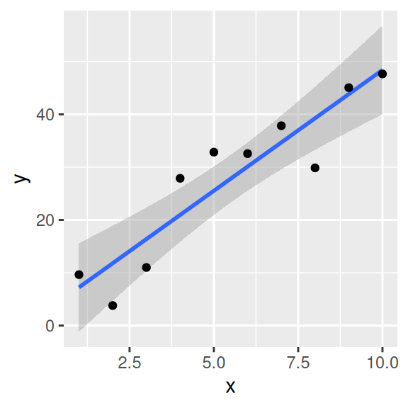

```r
dat |>
  ggplot(aes(y = y, x = x)) +
  geom_smooth(method = "lm") +
  geom_point()
```

**Conclusions**

- the spread of values around the trendline seems fairly even (hence it there is no evidence of non-homogeneity

**Linearity**

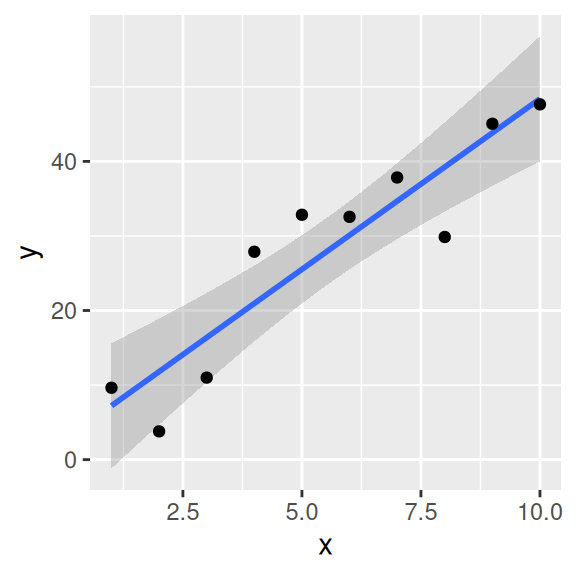

```r
dat |>
  ggplot(aes(y = y, x = x)) +
  geom_smooth(method = "lm") +
  geom_point()
```

**Conclusions**

**Conclusions**

- there are no obvious violations of the linear regression model assumptions
- we can now fit the suggested model
- full confirmation about the model’s goodness of fit should be reserved until after exploring the additional diagnostics that are only available after fitting the model.

**Example 2 (categorical predictor)**

**Normality**

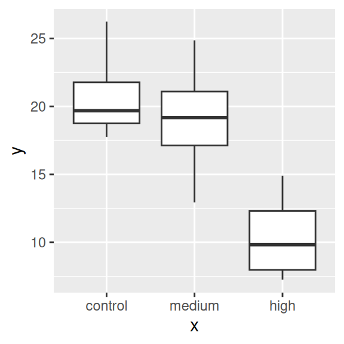

```r
dat2 |>
  ggplot(aes(y = y, x = x)) +
  geom_boxplot()
```

**Conclusions**

- there is no consitent evidence of non-normality across all groups
- even though the control group demonstrates some evidence of non-normality

**Homogeneity of variance**

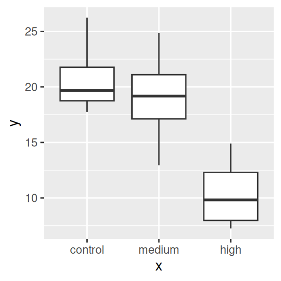

```r
dat2 |>
  ggplot(aes(y = y, x = x)) +
  geom_boxplot()
```

**Conclusions**

- the spread of noise in each group seems reasonably similar
- more importantly, there does not seem to be a relationship between the mean (as approximated by the position of the boxplots along the y-axis) and the variance (as approximated by the spread of the boxplots).
- that is, the size of the boxplots do not vary with the elevation of the boxplots.

**Linearity**

Linearity is not an issue for categorical predictors since it is effectively fitting separate lines between pairs of points (and a line between two points can only ever be linear)….

**Conclusions**